# Modelagem

Jonatha Azevedo, Leonardo Filgueira, George Amarante e Matheus Camelo

December 4, 2017

## Pegando os dados

Os dados usados na modelagem são referen a Produção Física Industrial sem ajuste sazonal com ano base 2012. Disponibilzados pelo IBGE (Instituto Brasileiro de Geografia e Estatística).

```r
require(BETS)
require(forecast)
require(normtest)
require(TSA)
require(dygraphs)
require(tidyr)
dados <-  BETS.sidra.get(x = c(3653), from = c("200201"), to = c("201710"), territory = "brazil",variable = 3135, sections = c(129316), cl = 544)
dados <- ts(dados$serie_3653$Valor,start = c(2002,01),frequency = 12)
dados <- window(dados,start = c(2002,01),end =c(2017,09),freq=12)
```

```r
dygraph(dados) %>% dyRangeSelector()
```

[interactive chart not shown]

É interessante notar o logarítimo dos dados, ele não muda de fato a série, mas veremos que ele nos ajuda a controlar os resíduos.

Antes de ir para o modo manual de identificação e estimação do modelo, vamos usar a função `auto.arima()`. A função nos dará um modelo, considerando as combinações feitas internamente no algoritmo.

```r
modelo_auto.arima <- auto.arima(dados);modelo_auto.arima
```

```
## Series: dados
## ARIMA(2,1,2)(1,1,2)[12]
##
## Coefficients:
##           ar1      ar2     ma1     ma2     sar1     sma1     sma2
##       -1.0340  -0.8395  0.7152  0.5747  -0.6092  -0.1338  -0.6208
## s.e.   0.0766   0.0847  0.1284  0.1291   0.2693   0.2541   0.1960
##
## sigma^2 estimated as 7.428:  log likelihood=-430.23
## AIC=876.46   AICc=877.32   BIC=901.82
```

### Analisando as correlações e correlações parciais

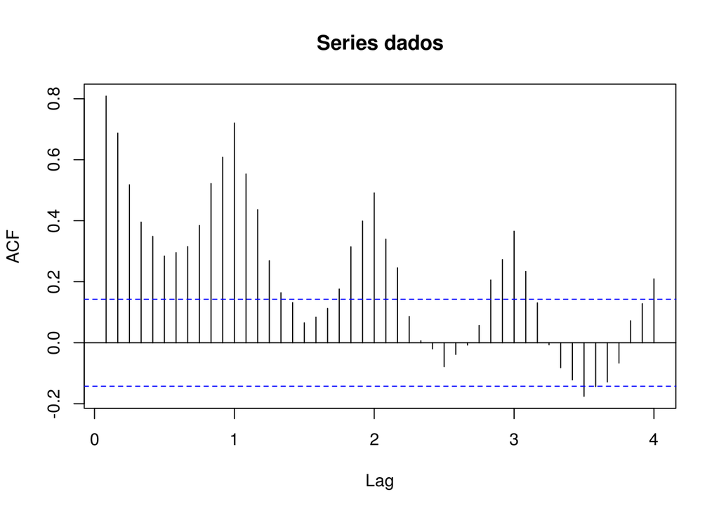

```r
acf(dados,lag.max = 48)
```

Os dados são claramente não estacionário. Podemos considerar o teste de estacionáriedade:

```r
adf.test(dados)
```

```
##
##  Augmented Dickey-Fuller Test
##
## data:  dados
## Dickey-Fuller = -3.5417, Lag order = 5, p-value = 0.04036
## alternative hypothesis: stationary
```

o `adf.test()` é um teste não paramétrico que pode ser não muito confiável. Vemos nesse caso que ele nos faz assumir características que não estão presente nos dados. Partimos para as diferenciações:

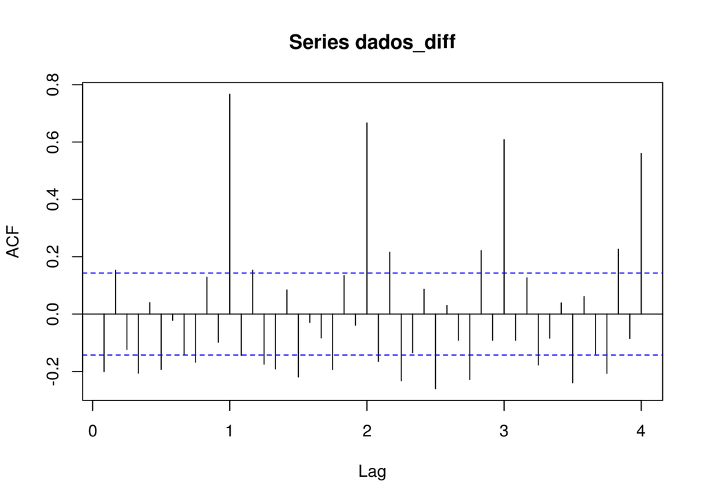

```r
dados_diff <- diff(dados)
acf(dados_diff,lag.max = 48)
```

Testando a estacionariedade com os dados diferenciados

```r
adf.test(dados_diff)
```

```
##
##  Augmented Dickey-Fuller Test
##
## data:  dados_diff
## Dickey-Fuller = -7.8376, Lag order = 5, p-value = 0.01
## alternative hypothesis: stationary
```

Fazendo mais uma dirença, na parte sazonal, temos:

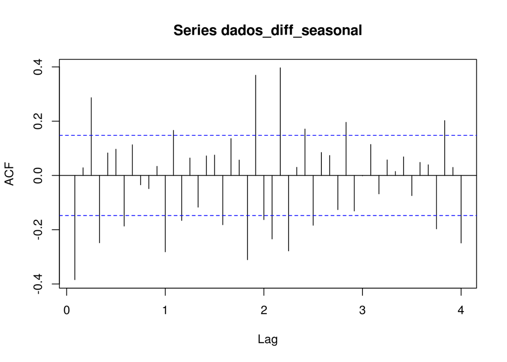

```r
dados_diff_seasonal = diff(dados_diff,lag=12)
acf(dados_diff_seasonal,lag=48)
```

Para a parte autorregressiva sazonal:

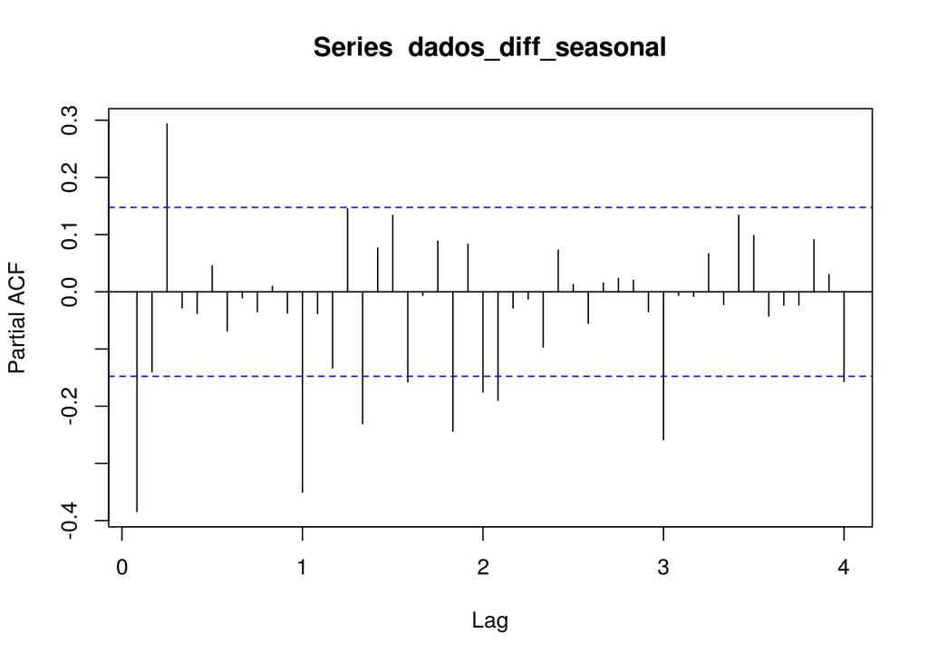

```r
pacf(dados_diff_seasonal,lag=48)
```

Ordem 3 para a parte autorregressiva não sazonal e 1 ordem para a parte autorregressiva na parte sazonal.

```r
modelo = Arima(dados,order= c(3,1,2),seasonal = c(1,1,1),lambda = 0)
modelo$aic
```

```
## [1] -727.8361
```

Veja a significância dos parametros com a BETS.t_test():

```r
BETS.t_test(modelo)
```

```
##            Coeffs Std.Errors           t Crit.Values Rej.H0
## ar1  -1.449189196 0.07537650 19.22600703    1.973231   TRUE
## ar2  -1.340500768 0.08640730 15.51374445    1.973231   TRUE
## ar3  -0.295320253 0.07494569  3.94045691    1.973231   TRUE
## ma1   1.165910594 0.02355664 49.49392882    1.973231   TRUE
## ma2   0.999456689 0.02919068 34.23889986    1.973231   TRUE
## sar1 -0.006237706 0.09823482  0.06349791    1.973231  FALSE
## sma1 -0.803883435 0.07820026 10.27980563    1.973231   TRUE
```

Vemos que o parametro autorregressivo sazonal é não significativo e é preciso retirá-lo do modelo:

```r
modelo = Arima(dados,order= c(3,1,2),seasonal = c(0,1,1),lambda = 0)
modelo$aic
```

```
## [1] -729.8327
```

Note que o parâmetro **`lambda`** receb o valor **`0`**. Isso significa que transformamos os dados passando o **`log`**. Usualmente, buscamos uma transformação pra controlar a variação, dessa forma, conseguimos captar melhor o modelo. Porém, nesse caso específico, o log nos ajuda a controlar os resíduos.

```r
BETS.t_test(modelo)
```

```
##          Coeffs Std.Errors         t Crit.Values Rej.H0
## ar1  -1.4494937 0.07524682 19.263190    1.973157   TRUE
## ar2  -1.3408489 0.08622321 15.550904    1.973157   TRUE
## ar3  -0.2956299 0.07478649  3.952985    1.973157   TRUE
## ma1   1.1660209 0.02354924 49.514169    1.973157   TRUE
## ma2   0.9993935 0.02867242 34.855570    1.973157   TRUE
## sma1 -0.8075343 0.06415542 12.587157    1.973157   TRUE
```

Com o auxílio da função **`BETS.t_test()`**, podemos verificar se os parametros do nosso modelo são significativos. Basicamente, é dividir a estimativa pelo desvio padrão. Dando diferente de 0, rejeitamos.

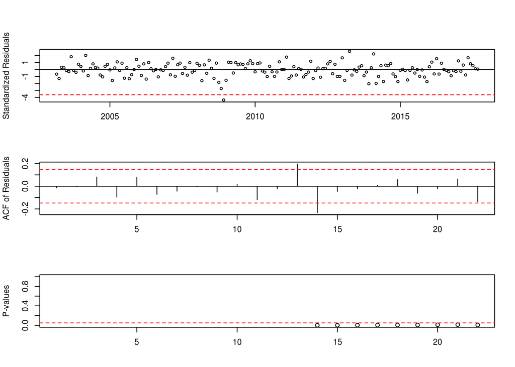

```r
tsdiag(modelo)
```

```r
shapiro.test(modelo$residuals)
```

```
##
##  Shapiro-Wilk normality test
##
## data:  modelo$residuals
## W = 0.97852, p-value = 0.005241
```

```r
x = (modelo$residuals - mean(modelo$residuals))/sd(modelo$residuals)
round(x)
```

```
##      Jan Feb Mar Apr May Jun Jul Aug Sep Oct Nov Dec
## 2002   0   0   0   0   0   0   0   0   0   0   0   0
## 2003  -1   0  -1  -1   0   0   0   0   2   0   0   1
## 2004   1   0   2  -1   0   1   0   0  -1  -1   1   1
## 2005   0  -2   0   1   0   1  -1   0  -1  -1   0   2
## 2006   1  -1   1  -1   1   0   0   0  -1   0   0   0
## 2007   1  -1   2  -1   1   1  -1   0  -1   1   0   0
## 2008   1   1  -2   1  -1   1   0  -1   1  -2  -3  -5
## 2009  -2   1   1   0   1   1   1   1   0   1   1   1
## 2010   0   1   1   0   0  -1   1   0  -1   0   1   0
## 2011   0   2  -1  -1   0  -1   0   0  -1  -1   0   1
## 2012  -1   0   0  -1   0   0   1   1  -1   1  -1  -1
## 2013   2  -2   0   3  -1   0   0   0   1  -1   0  -2
## 2014   0   2  -2  -1   1  -2   1   1   1  -1  -1  -2
## 2015   0   0   0  -2   0   0   0   0  -1   0  -1  -2
## 2016   0   1  -1   2  -1   1   0   0   0  -1   0   0
## 2017   1   0   1  -1   2   1   1   0   0
```

O interessante observar que esse outlier está atrelado a crise econômica (**-5, valor em dez/2008**). A série sofre bastante com essa quebra estrutural. Como dito anteriormente, assume um valor muito discrepante do resto dos dados.

Então, criamos uma variável explicativa para os resíduos, pois sem ela, dificilmente o modelo conseguiria captar. Utilizando a função **`BETS.dummy`**, temos:

```r
dummy <-  BETS.dummy(start = c(2002,01),end = c(2017,09),month =12 ,year = 2008 ,frequency = 12)
dummy
```

```
##      Jan Feb Mar Apr May Jun Jul Aug Sep Oct Nov Dec
## 2002   0   0   0   0   0   0   0   0   0   0   0   0
## 2003   0   0   0   0   0   0   0   0   0   0   0   0
## 2004   0   0   0   0   0   0   0   0   0   0   0   0
## 2005   0   0   0   0   0   0   0   0   0   0   0   0
## 2006   0   0   0   0   0   0   0   0   0   0   0   0
## 2007   0   0   0   0   0   0   0   0   0   0   0   0
## 2008   0   0   0   0   0   0   0   0   0   0   0   1
## 2009   0   0   0   0   0   0   0   0   0   0   0   0
## 2010   0   0   0   0   0   0   0   0   0   0   0   0
## 2011   0   0   0   0   0   0   0   0   0   0   0   0
## 2012   0   0   0   0   0   0   0   0   0   0   0   0
## 2013   0   0   0   0   0   0   0   0   0   0   0   0
## 2014   0   0   0   0   0   0   0   0   0   0   0   0
## 2015   0   0   0   0   0   0   0   0   0   0   0   0
## 2016   0   0   0   0   0   0   0   0   0   0   0   0
## 2017   0   0   0   0   0   0   0   0   0
```

Uma dummy é uma variável qualitativa, sendo o caso mas simples a variável que atribui 1 para uma categoria e 0 para a categoria mutuamente exclusiva a primeira.

Com a variável criada, reestimamos o modelo adicionando essa variável dummy com o parâmetro **`xreg`** na função **`Arima()`**.

```r
modelo2 <- Arima(dados,order= c(3,1,2),seasonal = c(0,1,1),lambda = 0,xreg=dummy)
modelo2$aic
```

```
## [1] -729.262
```

Verificando o gráfico dos resíduos com o **`tsdiag`**, temos:

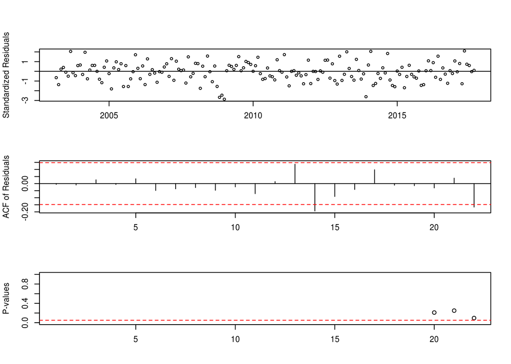

```r
tsdiag(modelo2)
```

Já podemos verificar uma grande melhora:

- Os resíduos paracem flutuar melhor em torno de 0 e não temos mais outlier, mas podemos ver pelo teste de normalidade:

```r
shapiro.test(modelo2$residuals)
```

```
##
##  Shapiro-Wilk normality test
##
## data:  modelo2$residuals
## W = 0.98781, p-value = 0.1039
```

Repetindo, verificamos quais parâmetros do novo modelo são significatens com a função **`BETS.t_test()`**:

```r
BETS.t_test(modelo2)
```

```
##            Coeffs Std.Errors          t Crit.Values Rej.H0
## ar1   -1.08991947 0.30593140  3.5626270    1.973157   TRUE
## ar2   -0.89770178 0.36031799  2.4914153    1.973157   TRUE
## ar3   -0.04273486 0.20991138  0.2035852    1.973157  FALSE
## ma1    0.70873332 0.30279401  2.3406451    1.973157   TRUE
## ma2    0.55931671 0.23620363  2.3679429    1.973157   TRUE
## sma1  -0.78668213 0.06967847 11.2901757    1.973157   TRUE
## dummy -0.07727876 0.02191596  3.5261406    1.973157   TRUE
```

Podemos ver que a dummy é significativa, o que corrobora com a necessidade de introduzi-la ao modelo para controlar os resíduos, mas que o terceiro parâmetro da parte autorregressiva não é significativo e precisamos retirá-lo.

```r
modelo3 <- Arima(dados,order = c(2,1,2),seasonal = c(0,1,1),lambda = 0,xreg=dummy)
modelo3$aic
```

```
## [1] -731.2142
```

E verificando os resíduos:

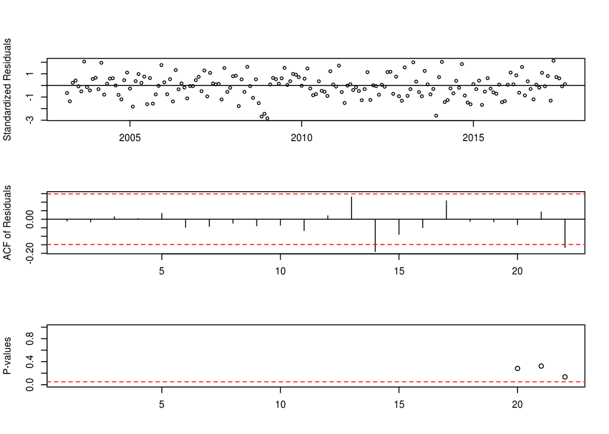

```r
tsdiag(modelo3)
```

Agora temos condições melhores com esse modelo. Podemos verificar a normalidade com o **`shapiro.test()`**

```r
shapiro.test(modelo3$residuals)
```

```
##
##  Shapiro-Wilk normality test
##
## data:  modelo3$residuals
## W = 0.98885, p-value = 0.1457
```

E temos normalidade, com **`p-value = 0.15`**, não rejeitamos a hipótese de normalidade dos resíduos.

Concluimos que o nosso modelo é: **SARIMA(2,1,2)(0,1,1)[12] com uma variável dummy para o mês de dezembro de 2008**.

A fim de comparação, podemos usar a função `auto.arima` novamente só que introduzindo a dummy craiada anteriormente para controlar o outlier de dezembro de 2008.

```r
modelo2_auto.arima <-  auto.arima(dados,xreg = dummy,lambda = 0)
modelo2_auto.arima$aic
```

```
## [1] -731.0382
```

Comparando os AIC’s, temos que o auto.arima com a dummy tem um AIC tão bom quanto o modelo criado olhando as facs e facps.

#### Previsões

Faremos a previsão para o ano de 2017, ou seja, para os meses de janeiro a setembro de 2017. Com isso, teremos duas abordagem:

- A primeira é fazer previsão mês a mês. Faremos a previsão para um mês, cortaremos os dados, adicionando o valor referente a essa previsão e assim partimos pro próximo mês. A ideia é que a cada mês a previsão seja “melhorada” adicionando um informação nova, mas logo imediatamente anteiror;
- A segunda abordagem é a mais usual. Faremos a previsão direto para esses 9 meses, de uma vez só.

Para isso, criamos uma função que otimiza esse calculo e nos dá os valores das duas abordagem:

```r
funcao <- function(h,dados,order,seasonal,lambda){
  #definições premiliminares
  previsoes = c()
  n <- length(dados)
  i = h

  # esse for é para a previsão mês a mês
  for(i in h:1){
    y <- ts(dados[1:(n-i)],start=start(dados),freq=12)
    y_dummy <- ts(dummy[1:(n-i)],start=start(dados),freq=12)
    y_dummy_prev = tail(ts(dummy[1:(n-i+1)],start=start(dados),freq=12),1)
    # para a previsão, precisamos reestimar o modelo, nesse caso,
    # mês a mês.
    aux2 <- Arima(y,order = order,seasonal = seasonal,lambda = lambda,xreg=y_dummy)
    previsoes[i] <- forecast(aux2,h=1,xreg = y_dummy_prev)$mean
  }
  # daqui para frente, temos a previsão para os meses de um vez só!
    previsoes = ts(previsoes[h:1],end = end(dados),freq = 12)

    y <- ts(dados[1:(n-h)],start=start(dados),freq=12)
    y_dummy2 = ts(dummy[1:(n-h)],start=start(dados),freq=12)
    # para a previsão, precisamos reestimar o modelo
    aux1 <- Arima(y,order = order,seasonal = seasonal,lambda = lambda,xreg=y_dummy2)

    y_dummy_prev2 <- ts(dummy[(n-h+1):n],end=end(dados),freq=12)
    previsao2 <- forecast(aux1,h=h,xreg = y_dummy_prev2)$mean

    ##comparando as previsões junto com os dados originais
    ts.plot(previsoes,previsao2,col=c(1,4),lty = c(1,2))
    lines(dados,col=2,lty = c(3))
    legend("topleft",legend = c("Dados","prev. mes a mes", "previsao normal"),lty = c(1,2,3),col = c(1,2,4),bty="n")

    return(list(prev1 = previsoes, prev2 = previsao2))
}
```

Com uma passada rápida pelos parâmetros, temos:

- *h* é a quantidade de valores que queremos prever;
- *dados* ferente aos dados, série temporal em estudo;
- *order* é a ordem autorregressiava do nosso modelo geral SARIMA;
- *seasonal* é a ordem da parte sazonal do nosso modelo geral SARIMA;
- *lambda* é referente a transformação dos dados em log(x).

```r
order = c(2,1,2)
seasonal = c(0,1,1)
h=9
prev <- funcao(h=h,dados=dados,order=order,seasonal = seasonal,lambda = 0)
```

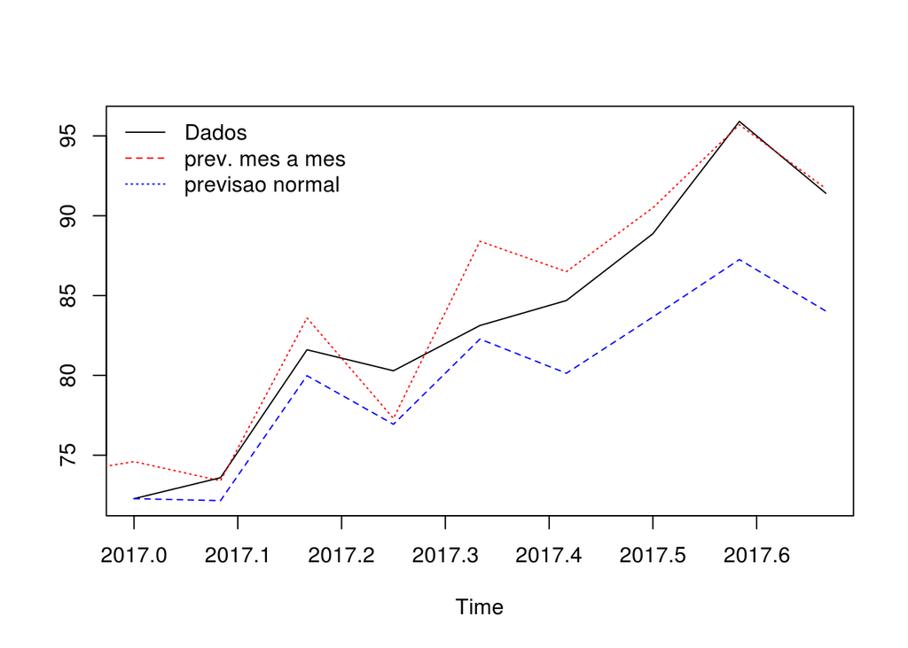

Vamos calcular o erro de previsão e descobrir qual, de fato, é melhor.

```r
comparacao <-  window(dados, start = c(2017,01),freq=12)
comparacao
```

```
##       Jan  Feb  Mar  Apr  May  Jun  Jul  Aug  Sep
## 2017 74.6 73.4 83.6 77.3 88.4 86.5 90.5 95.7 91.7
```

```r
prev$prev1
```

```
##           Jan      Feb      Mar      Apr      May      Jun      Jul
## 2017 72.27898 73.59235 81.60428 80.28895 83.12561 84.69146 88.87438
##           Aug      Sep
## 2017 95.90641 91.40606
```

```r
prev$prev2
```

```
##           Jan      Feb      Mar      Apr      May      Jun      Jul
## 2017 72.27898 72.15500 79.98368 76.93669 82.27669 80.13434 83.65760
##           Aug      Sep
## 2017 87.25631 84.02800
```

```r
#Erro médio quadrático
```

```r
(mean((comparacao - prev$prev1)^2))
```

```
## [1] 5.800271
```

```r
(mean((comparacao - prev$prev2)^2))
```

```
## [1] 30.57082
```

```r
#map
#Erro absoluto percentual médio
mean(abs(comparacao - prev$prev1)/comparacao)*100
```

```
## [1] 2.224116
```

```r
mean(abs(comparacao - prev$prev2)/comparacao)*100
```

```
## [1] 5.404371
```

Com isso, concluímos que a previsão com o procedimento mês a mês é melhor porque apresenta valores mais próximos do real.